# Bank loan credit dataset, visualization and maximization of profit

Exploring bank creddit data with Python programming language.

**Project Overview**

*Minimization of risk and maximization of profit on behalf of the bank.* The bank have has recorded a spate of NPA’s (non-performing assets) that, among other things—comprises of bad loans given out to the private consumers. The fiscal pressure has, therefore set the alarm bells ringing across all the managerial levels and hierarchy. The quest is simple—minimizes losses. A series of data for past customers pertaining to the loan applications has been collected.

```
When a bank gets a loan application, the bank must decide whether or not to go ahead with the loan process based on the applicant's profile. In this scenario, two types of risks are associated with the bank’s decision –
•   If the applicant is a good credit risk, i.e. is likely to repay the loan, then not approving the loan to the person results in a loss of business to the bank. And,
•   If the applicant is a bad credit risk, i.e. is not likely to repay the loan, then approving the loan to the person results in a financial loss to the bank.

To minimize losses from the bank's perspective, the bank requires a decision framework as to who and who should not be approved the loan
```

The Nordic Kredit contains data on 20 variables and the classification whether an applicant is considered a Good or a Bad credit risk for 1000 loan applicants. A predictive model developed on this data is expected to provide bank manager guidance for making a decision whether to approve a loan to a prospective applicant based on his/her profiles.

```
Packages used-

Pandas: A Python package providing fast, flexible, and expressive data structures designed to make working with “relational” or “labeled” data both easy and intuitive. It aims to be the fundamental high-level building block for doing practical, real world data analysis in Python.

Numpy: It is a library for the Python programming language, adding support for large, multi-dimensional arrays and matrices, along with a large collection of high-level mathematical functions to operate on these arrays.

Matplotlib: Matplotlib is a plotting library for the Python programming language and its numerical mathematics extension NumPy. It provides an object-oriented API for embedding plots into applications using general-purpose GUI toolkits like Tkinter, wxPython, Qt, or GTK+.

Seaborn: Seaborn is a Python visualization library based on matplotlib. It provides a high-level interface for drawing attractive statistical graphics.

Plotly: Also a plotting library which creates interactive plots.

Scikit-learn: A python library which contains very good and efficient implementations of various machine learning algorithms.
```

**Importing all the necessary libraries**

```python
import pandas as pd
import numpy as np
import matplotlib.pyplot as plt
import seaborn as sns
from sklearn.linear_model import LogisticRegression
from sklearn.model_selection import train_test_split
from sklearn import metrics
from patsy import dmatrices



import scipy.stats
import random

import plotly.offline as py

py.init_notebook_mode(connected=True)
import plotly.graph_objs as go
import plotly.tools as tls
import warnings
from collections import Counter
%matplotlib inline
```

**Reading the dataset as csv dataframe using Pandas**

```python
w=pd.read_csv('Nordic_Kredit (1).csv')
```

```python
w.head(4)
```

|  | Creditability | Account Balance | Duration of Credit (month) | Payment Status of Previous Credit | Purpose | Credit Amount | Value Savings/Stocks | Length of current employment | Instalment per cent | Sex & Marital Status | Guarantors | Duration in Current address | Most valuable available asset | Age (years) | Concurrent Credits | Type of apartment | No of Credits at this Bank | Occupation | No of dependents | Telephone | Foreign Worker |
| --- | --- | --- | --- | --- | --- | --- | --- | --- | --- | --- | --- | --- | --- | --- | --- | --- | --- | --- | --- | --- | --- |
| 0 | 1 | 1 | 18 | 4 | 2 | 1049 | 1 | 2 | 4 | 2 | 1 | 4 | 2 | 21 | 3 | 1 | 1 | 3 | 1 | 1 | 1 |
| 1 | 1 | 1 | 9 | 4 | 0 | 2799 | 1 | 3 | 2 | 3 | 1 | 2 | 1 | 36 | 3 | 1 | 2 | 3 | 2 | 1 | 1 |
| 2 | 1 | 2 | 12 | 2 | 9 | 841 | 2 | 4 | 2 | 2 | 1 | 4 | 1 | 23 | 3 | 1 | 1 | 2 | 1 | 1 | 1 |
| 3 | 1 | 1 | 12 | 4 | 0 | 2122 | 1 | 3 | 3 | 3 | 1 | 2 | 1 | 39 | 3 | 1 | 2 | 2 | 2 | 1 | 2 |

# Exploratory Data Analysis and Visualization

**Checking for existence of null values**

```python
w.isnull().sum().sum()
```

```
0
```

```python
w.info()
```

```
<class 'pandas.core.frame.DataFrame'>
RangeIndex: 1000 entries, 0 to 999
Data columns (total 21 columns):
Creditability                        1000 non-null int64
Account Balance                      1000 non-null int64
Duration of Credit (month)           1000 non-null int64
Payment Status of Previous Credit    1000 non-null int64
Purpose                              1000 non-null int64
Credit Amount                        1000 non-null int64
Value Savings/Stocks                 1000 non-null int64
Length of current employment         1000 non-null int64
Instalment per cent                  1000 non-null int64
Sex & Marital Status                 1000 non-null int64
Guarantors                           1000 non-null int64
Duration in Current address          1000 non-null int64
Most valuable available asset        1000 non-null int64
Age (years)                          1000 non-null int64
Concurrent Credits                   1000 non-null int64
Type of apartment                    1000 non-null int64
No of Credits at this Bank           1000 non-null int64
Occupation                           1000 non-null int64
No of dependents                     1000 non-null int64
Telephone                            1000 non-null int64
Foreign Worker                       1000 non-null int64
dtypes: int64(21)
memory usage: 164.1 KB
```

Shape of data=(rows,columns)

```python
w.shape
```

```
(1000, 21)
```

**Getting all important information of all attributes of dataset**

```python
w.describe()
```

|  | Creditability | Account Balance | Duration of Credit (month) | Payment Status of Previous Credit | Purpose | Credit Amount | Value Savings/Stocks | Length of current employment | Instalment per cent | Sex & Marital Status | Guarantors | Duration in Current address | Most valuable available asset | Age (years) | Concurrent Credits | Type of apartment | No of Credits at this Bank | Occupation | No of dependents | Telephone | Foreign Worker |
| --- | --- | --- | --- | --- | --- | --- | --- | --- | --- | --- | --- | --- | --- | --- | --- | --- | --- | --- | --- | --- | --- |
| count | 1000.000000 | 1000.000000 | 1000.000000 | 1000.00000 | 1000.000000 | 1000.00000 | 1000.000000 | 1000.000000 | 1000.000000 | 1000.00000 | 1000.000000 | 1000.000000 | 1000.000000 | 1000.00000 | 1000.000000 | 1000.000000 | 1000.000000 | 1000.000000 | 1000.000000 | 1000.000000 | 1000.000000 |
| mean | 0.700000 | 2.577000 | 20.903000 | 2.54500 | 2.828000 | 3271.24800 | 2.105000 | 3.384000 | 2.973000 | 2.68200 | 1.145000 | 2.845000 | 2.358000 | 35.54200 | 2.675000 | 1.928000 | 1.407000 | 2.904000 | 1.155000 | 1.404000 | 1.037000 |
| std | 0.458487 | 1.257638 | 12.058814 | 1.08312 | 2.744439 | 2822.75176 | 1.580023 | 1.208306 | 1.118715 | 0.70808 | 0.477706 | 1.103718 | 1.050209 | 11.35267 | 0.705601 | 0.530186 | 0.577654 | 0.653614 | 0.362086 | 0.490943 | 0.188856 |
| min | 0.000000 | 1.000000 | 4.000000 | 0.00000 | 0.000000 | 250.00000 | 1.000000 | 1.000000 | 1.000000 | 1.00000 | 1.000000 | 1.000000 | 1.000000 | 19.00000 | 1.000000 | 1.000000 | 1.000000 | 1.000000 | 1.000000 | 1.000000 | 1.000000 |
| 25% | 0.000000 | 1.000000 | 12.000000 | 2.00000 | 1.000000 | 1365.50000 | 1.000000 | 3.000000 | 2.000000 | 2.00000 | 1.000000 | 2.000000 | 1.000000 | 27.00000 | 3.000000 | 2.000000 | 1.000000 | 3.000000 | 1.000000 | 1.000000 | 1.000000 |
| 50% | 1.000000 | 2.000000 | 18.000000 | 2.00000 | 2.000000 | 2319.50000 | 1.000000 | 3.000000 | 3.000000 | 3.00000 | 1.000000 | 3.000000 | 2.000000 | 33.00000 | 3.000000 | 2.000000 | 1.000000 | 3.000000 | 1.000000 | 1.000000 | 1.000000 |
| 75% | 1.000000 | 4.000000 | 24.000000 | 4.00000 | 3.000000 | 3972.25000 | 3.000000 | 5.000000 | 4.000000 | 3.00000 | 1.000000 | 4.000000 | 3.000000 | 42.00000 | 3.000000 | 2.000000 | 2.000000 | 3.000000 | 1.000000 | 2.000000 | 1.000000 |
| max | 1.000000 | 4.000000 | 72.000000 | 4.00000 | 10.000000 | 18424.00000 | 5.000000 | 5.000000 | 4.000000 | 4.00000 | 3.000000 | 4.000000 | 4.000000 | 75.00000 | 3.000000 | 3.000000 | 4.000000 | 4.000000 | 2.000000 | 2.000000 | 2.000000 |

```python
print ("Creditability numbers: ")
print (w["Creditability"].value_counts())
```

```
Creditability numbers:
1    700
0    300
Name: Creditability, dtype: int64
```

**Function to enable plotly on Google colab**

```python
def enable_plotly_in_cell():
  import IPython
  from plotly.offline import init_notebook_mode
  display(IPython.core.display.HTML('''
        <script src="/static/components/requirejs/require.js"></script>
  '''))
  init_notebook_mode(connected=False)
```

**Visualising the creditability distribution of entire dataset**

```python
enable_plotly_in_cell()
trace0 = go.Bar(
            x = w[w["Creditability"]== 1]["Creditability"].value_counts().index.values,
            y = w[w["Creditability"]== 1]["Creditability"].value_counts().values,
            name='Good credit'
    )

trace1 = go.Bar(
            x = w[w["Creditability"]== 0]["Creditability"].value_counts().index.values,
            y = w[w["Creditability"]== 0]["Creditability"].value_counts().values,
            name='Bad credit'
    )

data = [trace0, trace1]

layout = go.Layout(

)

layout = go.Layout(
    yaxis=dict(
        title='Count'
    ),
    xaxis=dict(
        title='Risk Variable'
    ),
    title='Target variable distribution'
)

fig = go.Figure(data=data, layout=layout)

py.iplot(fig, filename='grouped-bar')
```

```
Output hidden; open in https://colab.research.google.com to view.
```

In matplotlib as plotly isnt visible in html format

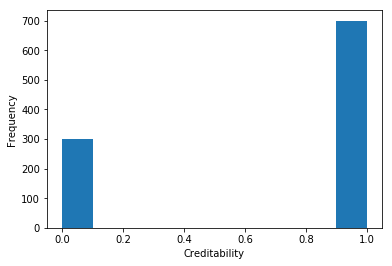

```python
plt.hist(w["Creditability"])
plt.xlabel("Creditability")
plt.ylabel("Frequency")
```

**Box plot of credit amount**

```python
enable_plotly_in_cell()
trace0 = go.Box(
    y=w["Credit Amount"],
    name='Credit Amount'
)
data = [trace0]
py.iplot(data)
```

```
Output hidden; open in https://colab.research.google.com to view.
```

In seaborn

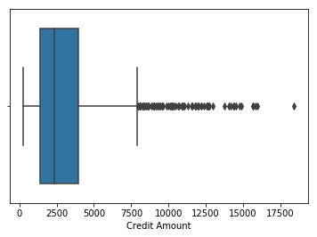

```python
sns.boxplot(w["Credit Amount"])
```

```python
w[w["Credit Amount"] >= 15000]
```

|  | Creditability | Account Balance | Duration of Credit (month) | Payment Status of Previous Credit | Purpose | Credit Amount | Value Savings/Stocks | Length of current employment | Instalment per cent | Sex & Marital Status | Guarantors | Duration in Current address | Most valuable available asset | Age (years) | Concurrent Credits | Type of apartment | No of Credits at this Bank | Occupation | No of dependents | Telephone | Foreign Worker |
| --- | --- | --- | --- | --- | --- | --- | --- | --- | --- | --- | --- | --- | --- | --- | --- | --- | --- | --- | --- | --- | --- |
| 645 | 1 | 1 | 36 | 2 | 10 | 15857 | 1 | 1 | 2 | 1 | 2 | 3 | 3 | 43 | 3 | 2 | 1 | 4 | 1 | 1 | 1 |
| 695 | 1 | 4 | 60 | 3 | 3 | 15653 | 1 | 4 | 2 | 3 | 1 | 4 | 3 | 21 | 3 | 2 | 2 | 3 | 1 | 2 | 1 |
| 810 | 0 | 2 | 48 | 2 | 9 | 15672 | 1 | 3 | 2 | 3 | 1 | 2 | 3 | 23 | 3 | 2 | 1 | 3 | 1 | 2 | 1 |
| 962 | 0 | 2 | 54 | 0 | 9 | 15945 | 1 | 2 | 3 | 3 | 1 | 4 | 4 | 58 | 3 | 1 | 1 | 3 | 1 | 2 | 1 |
| 976 | 0 | 2 | 48 | 0 | 10 | 18424 | 1 | 3 | 1 | 2 | 1 | 2 | 2 | 32 | 1 | 2 | 1 | 4 | 1 | 2 | 2 |

**Box plot of age (years)**

```python
enable_plotly_in_cell()
trace0 = go.Box(
    y=w["Age (years)"],
    name='Age (years)'
)
data = [trace0]
py.iplot(data)
```

```
Output hidden; open in https://colab.research.google.com to view.
```

In seaborn

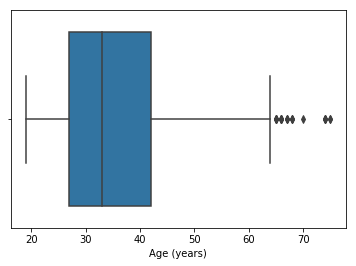

```python
sns.boxplot(w["Age (years)"])
```

```python
w[w["Age (years)"] < 20]
```

|  | Creditability | Account Balance | Duration of Credit (month) | Payment Status of Previous Credit | Purpose | Credit Amount | Value Savings/Stocks | Length of current employment | Instalment per cent | Sex & Marital Status | Guarantors | Duration in Current address | Most valuable available asset | Age (years) | Concurrent Credits | Type of apartment | No of Credits at this Bank | Occupation | No of dependents | Telephone | Foreign Worker |
| --- | --- | --- | --- | --- | --- | --- | --- | --- | --- | --- | --- | --- | --- | --- | --- | --- | --- | --- | --- | --- | --- |
| 298 | 1 | 2 | 12 | 2 | 2 | 983 | 4 | 2 | 1 | 2 | 1 | 4 | 1 | 19 | 3 | 1 | 1 | 2 | 1 | 1 | 1 |
| 819 | 0 | 4 | 9 | 2 | 2 | 1980 | 1 | 2 | 2 | 2 | 2 | 2 | 3 | 19 | 3 | 1 | 2 | 3 | 1 | 1 | 1 |

**Box plot of Duration of Credit (month)**

```python
enable_plotly_in_cell()
trace0 = go.Box(
    y=w["Duration of Credit (month)"],
    name='Duration of Credit (month)'
)
data = [trace0]
py.iplot(data)
```

```
Output hidden; open in https://colab.research.google.com to view.
```

In seaborn

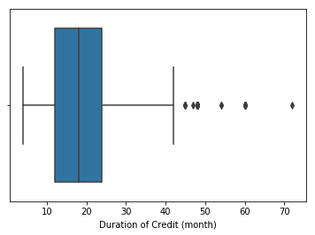

```python
sns.boxplot(w["Duration of Credit (month)"])
```

```python
w[w["Duration of Credit (month)"] >60]
```

|  | Creditability | Account Balance | Duration of Credit (month) | Payment Status of Previous Credit | Purpose | Credit Amount | Value Savings/Stocks | Length of current employment | Instalment per cent | Sex & Marital Status | Guarantors | Duration in Current address | Most valuable available asset | Age (years) | Concurrent Credits | Type of apartment | No of Credits at this Bank | Occupation | No of dependents | Telephone | Foreign Worker |
| --- | --- | --- | --- | --- | --- | --- | --- | --- | --- | --- | --- | --- | --- | --- | --- | --- | --- | --- | --- | --- | --- |
| 719 | 0 | 2 | 72 | 2 | 3 | 5595 | 2 | 3 | 2 | 4 | 1 | 2 | 3 | 24 | 3 | 2 | 1 | 3 | 1 | 1 | 1 |

**Histogram of Credit Amount**

```python
enable_plotly_in_cell()

data = [
  go.Histogram(
    histfunc = "count",
    x=w["Credit Amount"],
    nbinsx = 20,
    name = "credit amount"
  )
]

py.iplot(data)
```

```
Output hidden; open in https://colab.research.google.com to view.
```

In matplotlib

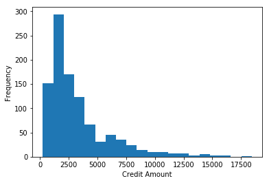

```python
plt.hist(w["Credit Amount"], bins = 20)
plt.xlabel("Credit Amount")
plt.ylabel("Frequency")
```

**Box plot of credit amount vs Creditability** We can see that there is a bit higher chance of credit being rejected if the amount is high

```python
enable_plotly_in_cell()
trace0 = go.Box(
    y=w["Credit Amount"],
    x=w["Creditability"],
    name='Credit amt vs creditability'
)
layout = go.Layout(
    yaxis=dict(
        title='Credit amt'
    ),
    xaxis=dict(
        title='creditability'
    ),
    title='Credit amt vs creditability'
)
data = [trace0]
fig = go.Figure(data=data, layout=layout)

py.iplot(fig, filename='aavva')
```

```
Output hidden; open in https://colab.research.google.com to view.
```

in seaborn

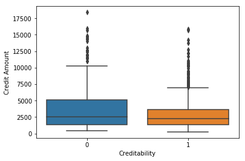

```python
sns.boxplot(x=w["Creditability"], y = w["Credit Amount"])
```

**Histogram of Age** We can see that maximum no of credit applications come from people between the age of 25 to 29 and gradually decreases from then on

```python
enable_plotly_in_cell()

data = [
  go.Histogram(
    histfunc = "count",
    x=w["Age (years)"],
    nbinsx = 16,
    name = "Age (years)"
  )
]
layout = go.Layout(
    yaxis=dict(
        title='Freq'
    ),
    xaxis=dict(
        title='Age bins'
    ),
    title='Age hist'
)
fig = go.Figure(data=data, layout=layout)

py.iplot(fig, filename='rshs')
```

```
Output hidden; open in https://colab.research.google.com to view.
```

In seaborn

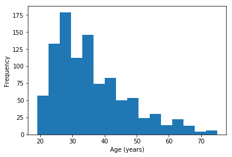

```python
plt.hist(w["Age (years)"], bins = 16)
plt.xlabel("Age (years)")
plt.ylabel("Frequency")
```

**Box plot of age (years) vs creditability**

```python
enable_plotly_in_cell()
trace0 = go.Box(
    y=w["Age (years)"],
    x=w["Creditability"],
    name='Age (years) vs creditability'
)
layout = go.Layout(
    yaxis=dict(
        title='Age (years)'
    ),
    xaxis=dict(
        title='creditability'
    ),
    title='Age (years) vs creditability'
)
data = [trace0]
fig = go.Figure(data=data, layout=layout)

py.iplot(fig, filename='aavva')
```

```
Output hidden; open in https://colab.research.google.com to view.
```

In seaborn

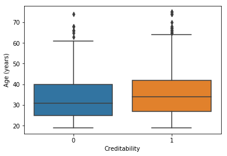

```python
sns.boxplot(x=w["Creditability"], y = w["Age (years)"])
```

**Histogram of Duration of Credit (month)** We can see that mostly duration varies from 10 to 24

```python
enable_plotly_in_cell()

data = [
  go.Histogram(
    histfunc = "count",
    x=w["Duration of Credit (month)"],
    nbinsx = 24,
    name = "Duration of Credit (month)"
  )
]
layout = go.Layout(
    yaxis=dict(
        title='Freq'
    ),
    xaxis=dict(
        title='Duration of Credit (month) bins'
    ),
    title='Duration of Credit (month) hist'
)
fig = go.Figure(data=data, layout=layout)

py.iplot(fig, filename='rshs')
```

```
Output hidden; open in https://colab.research.google.com to view.
```

In seaborn

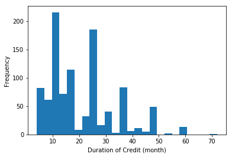

```python
plt.hist(w["Duration of Credit (month)"], bins = 24)
plt.xlabel("Duration of Credit (month)")
plt.ylabel("Frequency")
```

**Box plot of Duration of credit vs creditability** We can see that there is a higher chance of a loan getting approved if of shorter duration

```python
enable_plotly_in_cell()
trace0 = go.Box(
    y=w["Duration of Credit (month)"],
    x=w["Creditability"],
    name='Duration of Credit (month) vs creditability'
)
layout = go.Layout(
    yaxis=dict(
        title='Duration of Credit (month)'
    ),
    xaxis=dict(
        title='creditability'
    ),
    title='Duration of Credit (month) vs creditability'
)
data = [trace0]
fig = go.Figure(data=data, layout=layout)

py.iplot(fig, filename='aavva')
```

```
Output hidden; open in https://colab.research.google.com to view.
```

In seaborn

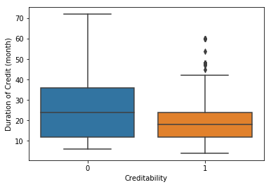

```python
sns.boxplot(x=w["Creditability"], y = w["Duration of Credit (month)"])
```

**Now we check distribution of various categorical variables**

```python
category_list = ["Duration of Credit (month)", "Credit Amount", "Age (years)"]
Data_categorical = w["Creditability"]
for col in w:
    if col not in category_list:
        category_tab = pd.crosstab(columns = w[col], index = "Percentage").apply(lambda r: (r/r.sum())*100, axis=1)
        category_tab.index = ["(%)"]
        print (category_tab)
```

```
Creditability     0     1
(%)            30.0  70.0
Account Balance     1     2    3     4
(%)              27.4  26.9  6.3  39.4
Payment Status of Previous Credit    0    1     2    3     4
(%)                                4.0  4.9  53.0  8.8  29.3
Purpose    0     1     2     3    4    5    6    8    9    10
(%)      23.4  10.3  18.1  28.0  1.2  2.2  5.0  0.9  9.7  1.2
Value Savings/Stocks     1     2    3    4     5
(%)                   60.3  10.3  6.3  4.8  18.3
Length of current employment    1     2     3     4     5
(%)                           6.2  17.2  33.9  17.4  25.3
Instalment per cent     1     2     3     4
(%)                  13.6  23.1  15.7  47.6
Sex & Marital Status    1     2     3    4
(%)                   5.0  31.0  54.8  9.2
Guarantors     1    2    3
(%)         90.7  4.1  5.2
Duration in Current address     1     2     3     4
(%)                          13.0  30.8  14.9  41.3
Most valuable available asset     1     2     3     4
(%)                            28.2  23.2  33.2  15.4
Concurrent Credits     1    2     3
(%)                 13.9  4.7  81.4
Type of apartment     1     2     3
(%)                17.9  71.4  10.7
No of Credits at this Bank     1     2    3    4
(%)                         63.3  33.3  2.8  0.6
Occupation    1     2     3     4
(%)         2.2  20.0  63.0  14.8
No of dependents     1     2
(%)               84.5  15.5
Telephone     1     2
(%)        59.6  40.4
Foreign Worker     1    2
(%)             96.3  3.7
```

We have encountered far too many categories. Merging those with low percentages

```python
w["Account Balance"].replace(4, 3, inplace = True)
```

new values (No account (1), None (No balance) (2), Some Balance (3))

```python
w["Payment Status of Previous Credit"].replace(0, 1, inplace = True)
w["Payment Status of Previous Credit"].replace(4, 3, inplace = True)
```

```python
w["Value Savings/Stocks"].replace(4, 3, inplace = True)
w["Value Savings/Stocks"].replace(5, 4, inplace = True)
```

```python
w["Occupation"].replace(2, 1, inplace = True)
w["Occupation"].replace(3, 2, inplace = True)
w["Occupation"].replace(4, 3, inplace = True)
```

New vals=> Unemployed/unskilled, Skilled , executive post

```python
w["Length of current employment"].replace(2, 1, inplace = True)
w["Length of current employment"].replace(3, 2, inplace = True)

w["Length of current employment"].replace(4, 3, inplace = True)
w["Length of current employment"].replace(5, 4, inplace = True)
```

Below 1 year (including unemployed), [1, 4), [4, 7), Above 7

```python
w["Sex & Marital Status"].replace(2, 1, inplace = True)
w["Sex & Marital Status"].replace(3, 2, inplace = True)
w["Sex & Marital Status"].replace(4, 3, inplace = True)
```

New vals=> male: divorced / living apart/Single, Male Married/Widowed, Female

```python
w["Guarantors"].replace(3, 2, inplace = True)
```

New vals=> None, Yes

```python
w["Concurrent Credits"].replace(2, 1, inplace = True)
w["Concurrent Credits"].replace(3, 2, inplace = True)
```

New vals=> Other Banks or Dept malls , None

```python
w["No of Credits at this Bank"].replace(3, 2, inplace = True)
w["No of Credits at this Bank"].replace(4, 2, inplace = True)
```

New vals=> 1, More than 1

```python
w["Purpose"].replace([3,4,5], 2, inplace = True)
w["Purpose"].replace([6,7,8,9,10], 3, inplace = True)
```

New vals=> new car, old car, home related, Important stuff

**New distribution of categorical variables**

```python
category_list = ["Duration of Credit (month)", "Credit Amount", "Age (years)"]
Data_categorical = w["Creditability"]
for col in w:
    if col not in category_list:
        category_tab = pd.crosstab(columns = w[col], index = "Percentage").apply(lambda r: (r/r.sum())*100, axis=1)
        category_tab.index = ["(%)"]
        print (category_tab)
```

```
Creditability     0     1
(%)            30.0  70.0
Account Balance     1     2     3
(%)              27.4  26.9  45.7
Payment Status of Previous Credit    0    1     2    3     4
(%)                                4.0  4.9  53.0  8.8  29.3
Purpose     0     1     2     3
(%)      23.4  10.3  49.5  16.8
Value Savings/Stocks     1     2     3     4
(%)                   60.3  10.3  11.1  18.3
Length of current employment     1     2     3     4
(%)                           23.4  33.9  17.4  25.3
Instalment per cent     1     2     3     4
(%)                  13.6  23.1  15.7  47.6
Sex & Marital Status     1     2    3
(%)                   36.0  54.8  9.2
Guarantors     1    2
(%)         90.7  9.3
Duration in Current address     1     2     3     4
(%)                          13.0  30.8  14.9  41.3
Most valuable available asset     1     2     3     4
(%)                            28.2  23.2  33.2  15.4
Concurrent Credits     1     2
(%)                 18.6  81.4
Type of apartment     1     2     3
(%)                17.9  71.4  10.7
No of Credits at this Bank     1     2
(%)                         63.3  36.7
Occupation     1     2     3
(%)         22.2  63.0  14.8
No of dependents     1     2
(%)               84.5  15.5
Telephone     1     2
(%)        59.6  40.4
Foreign Worker     1    2
(%)             96.3  3.7
```

Analysis of account balance types with Creditability

**Now performing chi square tests between categorical vars and creditability**

```python
q = pd.crosstab(w["Account Balance"], w["Creditability"], margins = True)
q
```

| Creditability Account Balance | 0 | 1 | All |
| --- | --- | --- | --- |
| 1 | 135 | 139 | 274 |
| 2 | 105 | 164 | 269 |
| 3 | 60 | 397 | 457 |
| All | 300 | 700 | 1000 |

```python
chi2, p, dof, exp = scipy.stats.chi2_contingency(q)
print (chi2)
print (p)
print (dof)
print (exp)
```

```
120.84376361168341
1.083531364440226e-23
6
[[  82.2  191.8  274. ]
 [  80.7  188.3  269. ]
 [ 137.1  319.9  457. ]
 [ 300.   700.  1000. ]]
```

```python
q = pd.crosstab(w["Payment Status of Previous Credit"], w["Creditability"], margins = True)
q
```

| Creditability Payment Status of Previous Credit | 0 | 1 | All |
| --- | --- | --- | --- |
| 0 | 25 | 15 | 40 |
| 1 | 28 | 21 | 49 |
| 2 | 169 | 361 | 530 |
| 3 | 28 | 60 | 88 |
| 4 | 50 | 243 | 293 |
| All | 300 | 700 | 1000 |

```python
chi2, p, dof, exp = scipy.stats.chi2_contingency(q)
print (chi2)
print (p)
print (dof)
print (exp)
```

```
61.6913969645955
1.7319995858582668e-09
10
[[  12.    28.    40. ]
 [  14.7   34.3   49. ]
 [ 159.   371.   530. ]
 [  26.4   61.6   88. ]
 [  87.9  205.1  293. ]
 [ 300.   700.  1000. ]]
```

**or we can perform in a single go**

```python
col_list = []
for col in w:
    col_list.append(col)
col_list
```

```
['Creditability',
 'Account Balance',
 'Duration of Credit (month)',
 'Payment Status of Previous Credit',
 'Purpose',
 'Credit Amount',
 'Value Savings/Stocks',
 'Length of current employment',
 'Instalment per cent',
 'Sex & Marital Status',
 'Guarantors',
 'Duration in Current address',
 'Most valuable available asset',
 'Age (years)',
 'Concurrent Credits',
 'Type of apartment',
 'No of Credits at this Bank',
 'Occupation',
 'No of dependents',
 'Telephone',
 'Foreign Worker']
```

**Loop to get Chi square results of every categorical variable with creditability**

```python
qq = []
for col in col_list:
    if col == "Creditability" or col =="Duration of Credit (month)" or col == "Credit Amount" or col == "Age (years)":
        pass
    else:
        q = pd.crosstab(w["Creditability"],w[col], margins = True)
        print (q)
        chi_stat, p_value, dof, expect_array  = scipy.stats.chi2_contingency(q, correction = True)
        msg = "Chi Test Statistic: {}\np-value: {}\ndof: {}"
        print (msg.format(chi_stat, p_value, dof))
        print ("                      ")
        if p_value < 0.05: #Threshold probability of 0.05
            qq.append(col)
```

```
Account Balance    1    2    3   All
Creditability
0                135  105   60   300
1                139  164  397   700
All              274  269  457  1000
Chi Test Statistic: 120.84376361168343
p-value: 1.0835313644402181e-23
dof: 6

Payment Status of Previous Credit   0   1    2   3    4   All
Creditability
0                                  25  28  169  28   50   300
1                                  15  21  361  60  243   700
All                                40  49  530  88  293  1000
Chi Test Statistic: 61.691396964595505
p-value: 1.7319995858582604e-09
dof: 10

Purpose          0    1    2    3   All
Creditability
0               89   17  132   62   300
1              145   86  363  106   700
All            234  103  495  168  1000
Chi Test Statistic: 22.558118924277036
p-value: 0.003980401807716201
dof: 8

Value Savings/Stocks    1    2    3    4   All
Creditability
0                     217   34   17   32   300
1                     386   69   94  151   700
All                   603  103  111  183  1000
Chi Test Statistic: 35.77973144465052
p-value: 1.9267670264020237e-05
dof: 8

Length of current employment    1    2    3    4   All
Creditability
0                              93  104   39   64   300
1                             141  235  135  189   700
```

[output cut: 97 more lines]

```
0              187  113   300
1              409  291   700
All            596  404  1000
Chi Test Statistic: 1.3297830262412609
p-value: 0.8563025242511287
dof: 4

Foreign Worker    1   2   All
Creditability
0               296   4   300
1               667  33   700
All             963  37  1000
Chi Test Statistic: 6.737044120221693
p-value: 0.15045408723319523
dof: 4
```

**All significant attributes with p value less than 0.05 listed below**

```python
print (qq)
```

```
['Account Balance', 'Payment Status of Previous Credit', 'Purpose', 'Value Savings/Stocks', 'Length of current employment', 'Most valuable available asset', 'Concurrent Credits', 'Type of apartment']
```

These are significant columns

Now handling continuous variables

```python
w.groupby(["Creditability"])["Credit Amount", "Duration of Credit (month)", "Age (years)"].mean()
```

| Creditability | Credit Amount | Duration of Credit (month) | Age (years) |
| --- | --- | --- | --- |
| 0 | 3938.126667 | 24.860000 | 33.96 |
| 1 | 2985.442857 | 19.207143 | 36.22 |

**We use ttest**

```python
z = w[w["Creditability"] == 0]["Credit Amount"]
zz = w[w["Creditability"] == 1]["Credit Amount"]
t_stat, p_ttest = scipy.stats.ttest_ind(z,zz)
print ("Credit Amount")
if p_ttest <= 0.05:
    print ("Everything goog")
    qq.append("Credit Amount")
else:
    print ("BAD")
```

```
Credit Amount
Everything goog
```

```python
z = w[w["Creditability"] == 0]["Age (years)"]
zz = w[w["Creditability"] == 1]["Age (years)"]
t_stat, p_ttest = scipy.stats.ttest_ind(z,zz)
print ("Age (years)")
if p_ttest <= 0.05:
    print ("Everything goog")
    qq.append("Age (years)")
else:
    print ("BAD")
z = w[w["Creditability"] == 0]["Duration of Credit (month)"]
zz = w[w["Creditability"] == 1]["Duration of Credit (month)"]
t_stat, p_ttest = scipy.stats.ttest_ind(z,zz)
print ("Duration of Credit (month)")
if p_ttest <= 0.05:
    print ("Everything goog")
    qq.append("Duration of Credit (month)")
else:
    print ("BAD")
```

```
Age (years)
Everything goog
Duration of Credit (month)
Everything goog
```

Both turned out to be significant as well

```python
qq
```

```
['Account Balance',
 'Payment Status of Previous Credit',
 'Purpose',
 'Value Savings/Stocks',
 'Length of current employment',
 'Most valuable available asset',
 'Concurrent Credits',
 'Type of apartment',
 'Credit Amount',
 'Age (years)',
 'Duration of Credit (month)']
```

**So total relevant features**

```python
features = w[['Account Balance',
 'Payment Status of Previous Credit',
 'Purpose',
 'Value Savings/Stocks',
 'Length of current employment',
 'Most valuable available asset',
 'Concurrent Credits',
 'Type of apartment',
 'Credit Amount',
 'Duration of Credit (month)',
 'Age (years)']]


labels = np.array(w["Creditability"])
```

# Model Building

We will be using Logistic Regression and Decision tree classifier

**Logistic Regression** ==> It is a technique of supervised learning. Logistic regression is a statistical model that in its basic form uses a logistic function to model a binary dependent variable, although many more complex extensions exist. In regression analysis, logistic regression (or logit regression) is estimating the parameters of a logistic model (a form of binary regression).This justifies the name ‘logistic regression’. Data is fit into linear regression model, which then be acted upon by a logistic function predicting the target categorical dependent variable. We will be using Binary Logistic Regression here as there are only 2 classes in which we have to classify.

[figure not shown]

This is the cost function of logisitc regression which is minimized.

**Decision Tree** ==>Decision tree learning is a method commonly used in Machine learinng. It is also a method for supervised learning. The goal is to create a model that predicts the value of a target variable based on several input variables. It is mainly used for classification though certain regressor variants of it also exist

[figure not shown]

An example of a simple decision tree.

A tree is built by splitting the source set, constituting the root node of the tree, into subsets - which constitute the successor children. The splitting is based on a set of splitting rules based on classification features. This process is repeated on each derived subset in a recursive manner called recursive partitioning. The recursion is completed when the subset at a node has all the same values of the target variable, or when splitting no longer adds value to the predictions.

**Trying one hot encoding**

```python
featuresonehot = features.copy()
featuresonehot = pd.get_dummies(featuresonehot, columns=['Account Balance',
 'Payment Status of Previous Credit',
 'Purpose',
 'Value Savings/Stocks',
 'Length of current employment',
 'Most valuable available asset',
 'Concurrent Credits',
 'Type of apartment'], prefix = ['Account Balance',
 'Payment Status of Previous Credit',
 'Purpose',
 'Value Savings/Stocks',
 'Length of current employment',
 'Most valuable available asset',
 'Concurrent Credits',
 'Type of apartment'])

print(featuresonehot.head())
```

```
   Credit Amount  ...  Type of apartment_3
0           1049  ...                    0
1           2799  ...                    0
2            841  ...                    0
3           2122  ...                    0
4           2171  ...                    0

[5 rows x 32 columns]
```

```python
featuresonehot.head()
```

|  | Credit Amount | Duration of Credit (month) | Age (years) | Account Balance_1 | Account Balance_2 | Account Balance_3 | Payment Status of Previous Credit_0 | Payment Status of Previous Credit_1 | Payment Status of Previous Credit_2 | Payment Status of Previous Credit_3 | Payment Status of Previous Credit_4 | Purpose_0 | Purpose_1 | Purpose_2 | Purpose_3 | Value Savings/Stocks_1 | Value Savings/Stocks_2 | Value Savings/Stocks_3 | Value Savings/Stocks_4 | Length of current employment_1 | Length of current employment_2 | Length of current employment_3 | Length of current employment_4 | Most valuable available asset_1 | Most valuable available asset_2 | Most valuable available asset_3 | Most valuable available asset_4 | Concurrent Credits_1 | Concurrent Credits_2 | … |
| --- | --- | --- | --- | --- | --- | --- | --- | --- | --- | --- | --- | --- | --- | --- | --- | --- | --- | --- | --- | --- | --- | --- | --- | --- | --- | --- | --- | --- | --- | --- |
| 0 | 1049 | 18 | 21 | 1 | 0 | 0 | 0 | 0 | 0 | 0 | 1 | 0 | 0 | 1 | 0 | 1 | 0 | 0 | 0 | 1 | 0 | 0 | 0 | 0 | 1 | 0 | 0 | 0 | 1 | … |
| 1 | 2799 | 9 | 36 | 1 | 0 | 0 | 0 | 0 | 0 | 0 | 1 | 1 | 0 | 0 | 0 | 1 | 0 | 0 | 0 | 0 | 1 | 0 | 0 | 1 | 0 | 0 | 0 | 0 | 1 | … |
| 2 | 841 | 12 | 23 | 0 | 1 | 0 | 0 | 0 | 1 | 0 | 0 | 0 | 0 | 0 | 1 | 0 | 1 | 0 | 0 | 0 | 0 | 1 | 0 | 1 | 0 | 0 | 0 | 0 | 1 | … |
| 3 | 2122 | 12 | 39 | 1 | 0 | 0 | 0 | 0 | 0 | 0 | 1 | 1 | 0 | 0 | 0 | 1 | 0 | 0 | 0 | 0 | 1 | 0 | 0 | 1 | 0 | 0 | 0 | 0 | 1 | … |
| 4 | 2171 | 12 | 38 | 1 | 0 | 0 | 0 | 0 | 0 | 0 | 1 | 1 | 0 | 0 | 0 | 1 | 0 | 0 | 0 | 0 | 1 | 0 | 0 | 0 | 1 | 0 | 0 | 1 | 0 | … |

Train test split of 30%

**Applying logistic regression**

Accuracy and confusion matrix

```python
from sklearn.model_selection import train_test_split
X_train, X_test, y_train, y_test = train_test_split(featuresonehot, label, test_size=0.30, random_state=42)
from sklearn.linear_model import LogisticRegression
l = LogisticRegression()
l.fit(X_train, y_train)
print (l)
pred = l.predict(X_test)
from sklearn.metrics import confusion_matrix, precision_recall_curve, auc, roc_auc_score, roc_curve, recall_score, classification_report

from sklearn.metrics import confusion_matrix
matrix = confusion_matrix(y_test,pred)
print(matrix)
print(classification_report(y_test,pred))
print(roc_auc_score(y_test,pred))
```

```
LogisticRegression(C=1.0, class_weight=None, dual=False, fit_intercept=True,
                   intercept_scaling=1, l1_ratio=None, max_iter=100,
                   multi_class='warn', n_jobs=None, penalty='l2',
                   random_state=None, solver='warn', tol=0.0001, verbose=0,
                   warm_start=False)
[[ 46  46]
 [ 24 184]]
              precision    recall  f1-score   support

           0       0.66      0.50      0.57        92
           1       0.80      0.88      0.84       208

    accuracy                           0.77       300
   macro avg       0.73      0.69      0.70       300
weighted avg       0.76      0.77      0.76       300

0.6923076923076923
```

**We get decent accuracy** Moreover the profit is getting maximized. If we take a profit of 0.35 on successful allottment of loan to a person which will not default and a loss of 1 if we allot a loan and the applicant defaults, we get profits= 18.4

**Using decision tree classifier**

Accuracy and confusion matrix

```python
from sklearn import tree
clf = tree.DecisionTreeClassifier()
clf = clf.fit(X_train, y_train)
pred=clf.predict(X_test)
from sklearn.metrics import confusion_matrix, precision_recall_curve, auc, roc_auc_score, roc_curve, recall_score, classification_report

from sklearn.metrics import confusion_matrix
matrix = confusion_matrix(y_test,pred)
print(matrix)
print(classification_report(y_test,pred))
print(roc_auc_score(y_test,pred))#base model
```

```
[[ 52  40]
 [ 61 147]]
              precision    recall  f1-score   support

           0       0.46      0.57      0.51        92
           1       0.79      0.71      0.74       208

    accuracy                           0.66       300
   macro avg       0.62      0.64      0.63       300
weighted avg       0.69      0.66      0.67       300

0.6359740802675586
```

**We get decent accuracy** Moreover the profit is getting maximized. If we take a profit of 0.35 on successful allottment of loan to a person which will not default and a loss of 1 if we allot a loan and the applicant defaults, we get profits= 11.45

Train test split of data 50%

```python
from sklearn.model_selection import train_test_split
X_train, X_test, y_train, y_test = train_test_split(features, label, test_size=0.50, random_state=1)
```

**Applying logistic regression**

```python
l = LogisticRegression()
l.fit(X_train, y_train)
print (l)
```

```
LogisticRegression(C=1.0, class_weight=None, dual=False, fit_intercept=True,
                   intercept_scaling=1, l1_ratio=None, max_iter=100,
                   multi_class='warn', n_jobs=None, penalty='l2',
                   random_state=None, solver='warn', tol=0.0001, verbose=0,
                   warm_start=False)
```

Accuracy and other measures including the confusion matrix

```python
pred = l.predict(X_test)
print ("Score of training data: ", l.score(X_train, y_train))
print ("Score of testing data: ", l.score(X_test, y_test))
print ("slope: ", l.coef_)
print ("intercept: ", l.intercept_)
matrix = confusion_matrix(y_test,pred)
print(matrix)
print(classification_report(y_test,pred))
print(roc_auc_score(y_test,pred))
```

```
Score of training data:  0.76
Score of testing data:  0.74
slope:  [[ 7.18301645e-01  2.32051683e-01  1.48621381e-01  2.09213533e-01
   2.73592793e-01 -3.44766483e-01 -3.62203982e-01  4.42172551e-01
   1.41987882e-05 -4.51687588e-02 -1.21191802e-02]]
intercept:  [-0.47503719]
[[ 62  87]
 [ 43 308]]
              precision    recall  f1-score   support

           0       0.59      0.42      0.49       149
           1       0.78      0.88      0.83       351

    accuracy                           0.74       500
   macro avg       0.69      0.65      0.66       500
weighted avg       0.72      0.74      0.73       500

0.6468001300216066
```

**We get decent accuracy** Moreover the profit is getting maximized. If we take a profit of 0.35 on successful allottment of loan to a person which will not default and a loss of 1 if we allot a loan and the applicant defaults, we get profits= 20.8

**Applying Decision tree**

```python
from sklearn import tree
clf = tree.DecisionTreeClassifier()
clf = clf.fit(X_train, y_train)
pred = clf.predict(X_test)
matrix = confusion_matrix(y_test,pred)
print(matrix)
print(classification_report(y_test,pred))
print(roc_auc_score(y_test,pred))
```

```
[[ 53  96]
 [ 83 268]]
              precision    recall  f1-score   support

           0       0.39      0.36      0.37       149
           1       0.74      0.76      0.75       351

    accuracy                           0.64       500
   macro avg       0.56      0.56      0.56       500
weighted avg       0.63      0.64      0.64       500

0.5596187307596704
```

**We get less accuracy** Moreover the profit is getting low. If we take a profit of 0.35 on successful allottment of loan to a person which will not default and a loss of 1 if we allot a loan and the applicant defaults, we get profits= -2.2

Decision tree does not work well here

**Train test split 30% and no one hot encoding**

```python
from sklearn.model_selection import train_test_split
X_train, X_test, y_train, y_test = train_test_split(features, label, test_size=0.30, random_state=42)
```

**Applying logistic regression**

```python
from sklearn.linear_model import LogisticRegression
l = LogisticRegression()
l.fit(X_train, y_train)
print (l)
```

```
LogisticRegression(C=1.0, class_weight=None, dual=False, fit_intercept=True,
                   intercept_scaling=1, l1_ratio=None, max_iter=100,
                   multi_class='warn', n_jobs=None, penalty='l2',
                   random_state=None, solver='warn', tol=0.0001, verbose=0,
                   warm_start=False)
```

```python
pred = l.predict(X_test)
```

Accuracy and other measures including the confusion matrix

```python
from sklearn.metrics import confusion_matrix, precision_recall_curve, auc, roc_auc_score, roc_curve, recall_score, classification_report

from sklearn.metrics import confusion_matrix
matrix = confusion_matrix(y_test,pred)
print(matrix)
print(classification_report(y_test,pred))
print(roc_auc_score(y_test,pred))
```

```
[[ 32  60]
 [ 24 184]]
              precision    recall  f1-score   support

           0       0.57      0.35      0.43        92
           1       0.75      0.88      0.81       208

    accuracy                           0.72       300
   macro avg       0.66      0.62      0.62       300
weighted avg       0.70      0.72      0.70       300

0.6162207357859532
```

**We get decent accuracy** Moreover the profit is getting maximized. If we take a profit of 0.35 on successful allottment of loan to a person which will not default and a loss of 1 if we allot a loan and the applicant defaults, we get profits= 4.4

**Applying Decision tree**

```python
from sklearn import tree
clf = tree.DecisionTreeClassifier()
clf = clf.fit(X_train, y_train)
```

Accuracy and other measures including confusion matrix

```python
pred=clf.predict(X_test)
from sklearn.metrics import confusion_matrix, precision_recall_curve, auc, roc_auc_score, roc_curve, recall_score, classification_report

from sklearn.metrics import confusion_matrix
matrix = confusion_matrix(y_test,pred)
print(matrix)
print(classification_report(y_test,pred))
print(roc_auc_score(y_test,pred))#base model
```

```
[[ 44  48]
 [ 37 171]]
              precision    recall  f1-score   support

           0       0.54      0.48      0.51        92
           1       0.78      0.82      0.80       208

    accuracy                           0.72       300
   macro avg       0.66      0.65      0.65       300
weighted avg       0.71      0.72      0.71       300

0.6501881270903009
```

**We get decent accuracy** Moreover the profit is getting maximized. If we take a profit of 0.35 on successful allottment of loan to a person which will not default and a loss of 1 if we allot a loan and the applicant defaults, we get profits= 11.85

**Now to see how good are our results compared to if we passed the data directly without any selection**

```python
w1=pd.read_csv('Nordic_Kredit (1).csv')
```

```python
corr = w1.corr()
```

**The correlation heatmap of various variables**

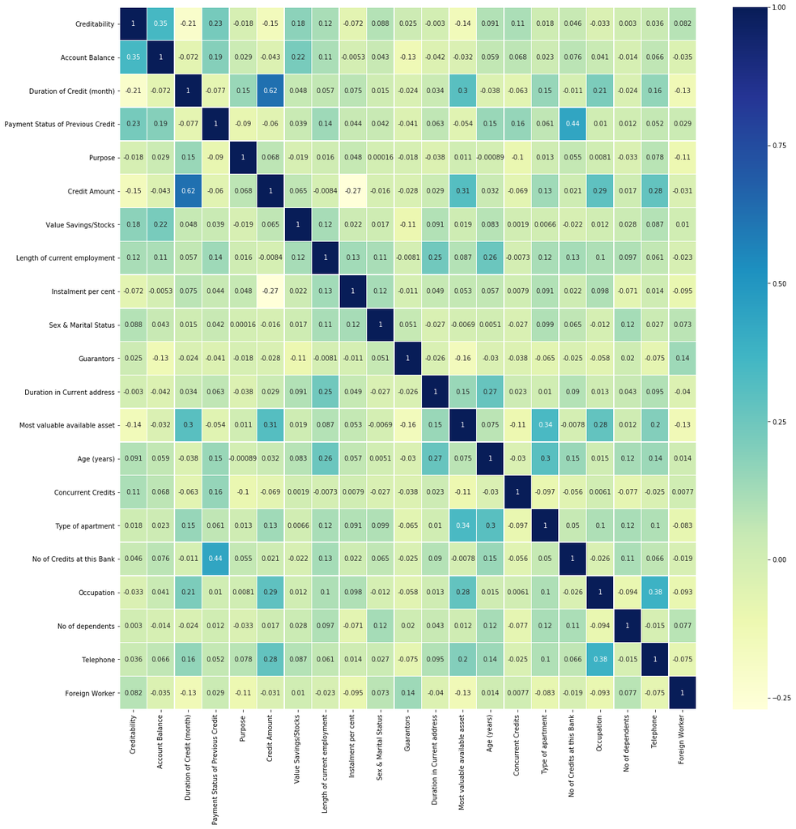

```python
import matplotlib.pyplot as plt

fig, ax = plt.subplots(figsize=(20,20))
sns.heatmap(corr,
        xticklabels=corr.columns,
        yticklabels=corr.columns,cmap="YlGnBu",linewidths=.5,ax=ax,annot=True)
```

```python
w1=w1.drop(columns=['Creditability'], axis=1)
```

```python
from sklearn.model_selection import train_test_split
```

**Train test split of 30%**

```python
X_train, X_test, y_train, y_test = train_test_split(w1, y, test_size=0.30, random_state=42)
```

**Applying decision tree classifier**

```python
from sklearn import tree
clf = tree.DecisionTreeClassifier()
clf = clf.fit(X_train, y_train)
```

```python
%matplotlib inline
```

Accuracy and confusion matrix

```python
pred=clf.predict(X_test)
from sklearn.metrics import confusion_matrix, precision_recall_curve, auc, roc_auc_score, roc_curve, recall_score, classification_report

from sklearn.metrics import confusion_matrix
matrix = confusion_matrix(y_test,pred)
print(matrix)
print(classification_report(y_test,pred))
print(roc_auc_score(y_test,pred))#base model
```

```
[[ 43  49]
 [ 40 168]]
              precision    recall  f1-score   support

           0       0.52      0.47      0.49        92
           1       0.77      0.81      0.79       208

    accuracy                           0.70       300
   macro avg       0.65      0.64      0.64       300
weighted avg       0.70      0.70      0.70       300

0.6375418060200668
```

**We get decent accuracy** However the profit is not getting as maximized as earlier. If we take a profit of 0.35 on successful allottment of loan to a person which will not default and a loss of 1 if we allot a loan and the applicant defaults, we get profits= 9.8 which are less than that obtained earlier.

```python
from sklearn.linear_model import LogisticRegression
l = LogisticRegression()
l.fit(X_train, y_train)
print (l)
```

```
LogisticRegression(C=1.0, class_weight=None, dual=False, fit_intercept=True,
                   intercept_scaling=1, l1_ratio=None, max_iter=100,
                   multi_class='warn', n_jobs=None, penalty='l2',
                   random_state=None, solver='warn', tol=0.0001, verbose=0,
                   warm_start=False)
```

```python
pred=l.predict(X_test)
from sklearn.metrics import confusion_matrix, precision_recall_curve, auc, roc_auc_score, roc_curve, recall_score, classification_report

from sklearn.metrics import confusion_matrix
matrix = confusion_matrix(y_test,pred)
print(matrix)
print(classification_report(y_test,pred))
print(roc_auc_score(y_test,pred))#base model
```

```
[[ 33  59]
 [ 21 187]]
              precision    recall  f1-score   support

           0       0.61      0.36      0.45        92
           1       0.76      0.90      0.82       208

    accuracy                           0.73       300
   macro avg       0.69      0.63      0.64       300
weighted avg       0.71      0.73      0.71       300

0.6288670568561874
```

**We get decent accuracy** However the profit is significantly low. If we take a profit of 0.35 on successful allottment of loan to a person which will not default and a loss of 1 if we allot a loan and the applicant defaults, we get profits= 6.45 as opposed to 18.4 we got earlier.

**Awesome!** So on 30% split, we maximized our profit upto 3 times

```python
!ipython nbconvert "drive/My Drive/Colab Notebooks/projfin.ipynb"
```

```
[TerminalIPythonApp] WARNING | Subcommand `ipython nbconvert` is deprecated and will be removed in future versions.
[TerminalIPythonApp] WARNING | You likely want to use `jupyter nbconvert` in the future
[NbConvertApp] Converting notebook drive/My Drive/Colab Notebooks/projfin.ipynb to html
[NbConvertApp] Writing 802673 bytes to drive/My Drive/Colab Notebooks/projfin.html
```

```python
from google.colab import drive
drive.mount('/content/drive')
```

[output not shown]